# How Can a Wellness Technology Company Play It Smart? A Bellabeat Case Study

Katie Carlberg

2023-02-26

[figure not shown]

## Summary

### Bellabeat is a high-tech company that manufactures health-focused smart products. They offer stylish products for women that collect data on activity, sleep, stress, and reproductive health. The company was founded in 2013 by Urška Sršen and Sando Mur and has expanded quickly since, now with the possibility to become a greater player in the global smart device market.

### Today, we are going to be analyzing smart device data to gain insight into how consumers are using their existing smart devices. This, in turn, will help us make recommendations that will guide the marketing strategy for the company, focusing specifically on the Bellabeat App and Membership.

### The Bellabeat app provides users with health data related to their activity, sleep, stress, menstrual cycle, and mindfulness habits. This data can help users better understand their current habits and make healthy decisions. The Bellabeat app connects to their line of smart wellness products.

### This case study follows the six-step data analysis process: Ask, Prepare, Process, Analyze, Share, and Act.

## Step One: Ask

### *Business Task*: Analyze competitor smart device (Fitbit) data to gain insight that will help guide the marketing strategy for Bellabeat in order to grow in the global market.

### *Primary stakeholders*: Urška Sršen and Sando Mur, co-founders of Bellabeat.

### *Secondary stakeholders*: Bellabeat marketing analytics team.

## Step Two: Prepare

### The data is **Cited** because we know it was gathered from fitbit users via Amazon, however we don’t know anything more specific than that.

### **This data has limitations.**

### There are only thirty participants in this sample, and we do not have key demographic information for them such as age, gender, race, and location. Without knowing this information, it is possible that this data contains bias and does not represent the general population as a whole. Therefore, we may only make general recommendations based upon the limited information gathered from this dataset.

### **Sorting and Filtering**

### Because of the small sample size, I decided to use Microsoft Excel to first sort and filter the data files before moving on to the process phase. By creating pivot tables and graphs within Excel, I was able to make the following determinations:

### • There are actually 33 unique user IDs in the Daily Activity data sets, 24 unique IDs in the Sleep sets, 14 in the Heartrate set, and only 8 IDs in the Weight Log set. (Found by using the **=SUM(1/COUNTIF())** formula.)

### • All of the datasets we are using contain the same ID column, therefore we can merge and transform these tables for analysis.

### • The study is found to have lasted precisely 31 days from start to finish. (Using the **=DATEDIF()** formula.)

### • Because the dailyActivity_merged table includes the same data as dailyCalories, dailyIntensities, and dailySteps, we can disregard these sets for our analysis.

### • The hourly and minute breakdowns of the datasets will not give us enough valuable information to be able to make general recommendations, therefore we will not be using these in our analysis either.

## Step Three: Process

[figure not shown]

### In order to analyze our data, we must first get it ready by cleaning and transforming the sets. This will give us the best possible data to then glean our results from.

### **For this task, I have chosen to use R.** The multitude of packages availble make this program ideal for cleaning and analyzing data.

### First we will install the packages needed for this project.

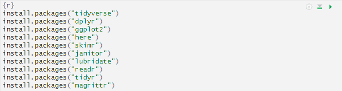

```r
library(tidyverse)
library(dplyr)
library(ggplot2)
library(here)
library(skimr)
library(janitor)
library(lubridate)
library(readr)
library(tidyr)
library(magrittr)
```

### Next, we will import our datasets as **Data Frames** with simplified names for ease of use.

```r
DailyActivity <- readr::read_csv("C:/Users/Dusk/Desktop/School/Projects/archive/Fitabase Data 4.12.16-5.12.16/dailyActivity_merged.csv")
Heartrate <- readr::read_csv("C:/Users/Dusk/Desktop/School/Projects/archive/Fitabase Data 4.12.16-5.12.16/heartrate_seconds_merged.csv")
SleepDay <- readr::read_csv("C:/Users/Dusk/Desktop/School/Projects/archive/Fitabase Data 4.12.16-5.12.16/sleepDay_merged.csv")
WeightLog <- readr::read_csv("C:/Users/Dusk/Desktop/School/Projects/archive/Fitabase Data 4.12.16-5.12.16/weightLogInfo_merged.csv")
```

### Now, we can preview the datasets by using the head() function.

```r
head(DailyActivity)
```

```
## # A tibble: 6 × 15
##       Id Activ…¹ Total…² Total…³ Track…⁴ Logge…⁵ VeryA…⁶ Moder…⁷ Light…⁸ Seden…⁹
##    <dbl> <chr>     <dbl>   <dbl>   <dbl>   <dbl>   <dbl>   <dbl>   <dbl>   <dbl>
## 1 1.50e9 4/12/2…   13162    8.5     8.5        0    1.88   0.550    6.06       0
## 2 1.50e9 4/13/2…   10735    6.97    6.97       0    1.57   0.690    4.71       0
## 3 1.50e9 4/14/2…   10460    6.74    6.74       0    2.44   0.400    3.91       0
## 4 1.50e9 4/15/2…    9762    6.28    6.28       0    2.14   1.26     2.83       0
## 5 1.50e9 4/16/2…   12669    8.16    8.16       0    2.71   0.410    5.04       0
## 6 1.50e9 4/17/2…    9705    6.48    6.48       0    3.19   0.780    2.51       0
## # … with 5 more variables: VeryActiveMinutes <dbl>, FairlyActiveMinutes <dbl>,
## #   LightlyActiveMinutes <dbl>, SedentaryMinutes <dbl>, Calories <dbl>, and
## #   abbreviated variable names ¹ActivityDate, ²TotalSteps, ³TotalDistance,
## #   ⁴TrackerDistance, ⁵LoggedActivitiesDistance, ⁶VeryActiveDistance,
## #   ⁷ModeratelyActiveDistance, ⁸LightActiveDistance, ⁹SedentaryActiveDistance
```

```r
head(Heartrate)
```

```
## # A tibble: 6 × 3
##           Id Time                 Value
##        <dbl> <chr>                <dbl>
## 1 2022484408 4/12/2016 7:21:00 AM    97
## 2 2022484408 4/12/2016 7:21:05 AM   102
## 3 2022484408 4/12/2016 7:21:10 AM   105
## 4 2022484408 4/12/2016 7:21:20 AM   103
## 5 2022484408 4/12/2016 7:21:25 AM   101
## 6 2022484408 4/12/2016 7:22:05 AM    95
```

```r
head(SleepDay)
```

```
## # A tibble: 6 × 5
##           Id SleepDay              TotalSleepRecords TotalMinutesAsleep TotalT…¹
##        <dbl> <chr>                             <dbl>              <dbl>    <dbl>
## 1 1503960366 4/12/2016 12:00:00 AM                 1                327      346
## 2 1503960366 4/13/2016 12:00:00 AM                 2                384      407
## 3 1503960366 4/15/2016 12:00:00 AM                 1                412      442
## 4 1503960366 4/16/2016 12:00:00 AM                 2                340      367
## 5 1503960366 4/17/2016 12:00:00 AM                 1                700      712
## 6 1503960366 4/19/2016 12:00:00 AM                 1                304      320
## # … with abbreviated variable name ¹TotalTimeInBed
```

```r
head(WeightLog)
```

```
## # A tibble: 6 × 8
##           Id Date                  WeightKg Weight…¹   Fat   BMI IsMan…²   LogId
##        <dbl> <chr>                    <dbl>    <dbl> <dbl> <dbl> <lgl>     <dbl>
## 1 1503960366 5/2/2016 11:59:59 PM      52.6     116.    22  22.6 TRUE    1.46e12
## 2 1503960366 5/3/2016 11:59:59 PM      52.6     116.    NA  22.6 TRUE    1.46e12
## 3 1927972279 4/13/2016 1:08:52 AM     134.      294.    NA  47.5 FALSE   1.46e12
## 4 2873212765 4/21/2016 11:59:59 PM     56.7     125.    NA  21.5 TRUE    1.46e12
## 5 2873212765 5/12/2016 11:59:59 PM     57.3     126.    NA  21.7 TRUE    1.46e12
## 6 4319703577 4/17/2016 11:59:59 PM     72.4     160.    25  27.5 TRUE    1.46e12
## # … with abbreviated variable names ¹WeightPounds, ²IsManualReport
```

### We can see with the head() function that all of our dates are entered as character data types. In order to use this data for analysis, we will need to transform the character data into date data. To do this, we will use the lubridate package as follows:

```r
DailyActivity$date <- lubridate::mdy(DailyActivity$ActivityDate)
```

### Now we can verify with the glimpse() function that a new column has been added to our dataframe named “date” and that it is in fact, in a date format. We will repeat these steps for all four of our dataframes.

```r
dplyr::glimpse(DailyActivity)
```

```
## Rows: 940
## Columns: 16
## $ Id                       <dbl> 1503960366, 1503960366, 1503960366, 150396036…
## $ ActivityDate             <chr> "4/12/2016", "4/13/2016", "4/14/2016", "4/15/…
## $ TotalSteps               <dbl> 13162, 10735, 10460, 9762, 12669, 9705, 13019…
## $ TotalDistance            <dbl> 8.50, 6.97, 6.74, 6.28, 8.16, 6.48, 8.59, 9.8…
## $ TrackerDistance          <dbl> 8.50, 6.97, 6.74, 6.28, 8.16, 6.48, 8.59, 9.8…
## $ LoggedActivitiesDistance <dbl> 0, 0, 0, 0, 0, 0, 0, 0, 0, 0, 0, 0, 0, 0, 0, …
## $ VeryActiveDistance       <dbl> 1.88, 1.57, 2.44, 2.14, 2.71, 3.19, 3.25, 3.5…
## $ ModeratelyActiveDistance <dbl> 0.55, 0.69, 0.40, 1.26, 0.41, 0.78, 0.64, 1.3…
## $ LightActiveDistance      <dbl> 6.06, 4.71, 3.91, 2.83, 5.04, 2.51, 4.71, 5.0…
## $ SedentaryActiveDistance  <dbl> 0, 0, 0, 0, 0, 0, 0, 0, 0, 0, 0, 0, 0, 0, 0, …
## $ VeryActiveMinutes        <dbl> 25, 21, 30, 29, 36, 38, 42, 50, 28, 19, 66, 4…
## $ FairlyActiveMinutes      <dbl> 13, 19, 11, 34, 10, 20, 16, 31, 12, 8, 27, 21…
## $ LightlyActiveMinutes     <dbl> 328, 217, 181, 209, 221, 164, 233, 264, 205, …
## $ SedentaryMinutes         <dbl> 728, 776, 1218, 726, 773, 539, 1149, 775, 818…
## $ Calories                 <dbl> 1985, 1797, 1776, 1745, 1863, 1728, 1921, 203…
## $ date                     <date> 2016-04-12, 2016-04-13, 2016-04-14, 2016-04-…
```

```r
Heartrate$date <- lubridate::mdy_hms(Heartrate$Time)
SleepDay$date <- lubridate::mdy_hms(SleepDay$SleepDay)
WeightLog$date_time <- lubridate::mdy_hms(WeightLog$Date)
```

### Next, we will check the datasets for duplicates.

```r
sum(duplicated(DailyActivity))
```

```
## [1] 0
```

```r
sum(duplicated(Heartrate))
```

```
## [1] 0
```

```r
sum(duplicated(SleepDay))
```

```
## [1] 3
```

```r
sum(duplicated(WeightLog))
```

```
## [1] 0
```

### Using the distinct() and drop_na() functions together, we can remove both the duplicates and the n/a entries from our datasets at the same time with the pipeline tool (%>%).

```r
DailyActivity <- DailyActivity %>%
  distinct() %>%
  drop_na()
Heartrate <- Heartrate %>%
  distinct() %>%
  drop_na()
SleepDay <- SleepDay %>%
  distinct() %>%
  drop_na()
WeightLog <- WeightLog %>%
  distinct() %>%
  drop_na()
```

### Let’s check to see if it worked.

```r
sum(duplicated(SleepDay))
```

```
## [1] 0
```